# Joao Garcia

## PhD Candidate, Brown University

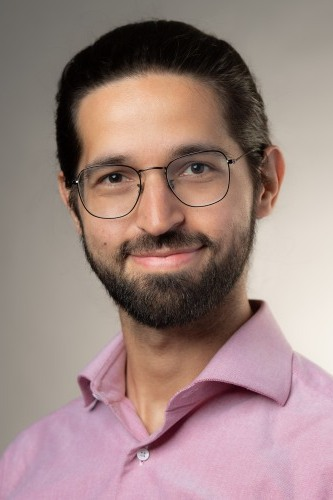

email: **joao_garcia@brown.edu**

## Research

### Optimizing Incentives for Rooftop Solar: Accounting for Regional Differences in Marginal Emissions

Although federal incentives for residential rooftop solar do not discriminate between US states, there is substantial variation in the marginal emission reductions associated with solar across states. This variation indicates potentially large efficiency gains from having flexible state-by-state incentives. In this paper I estimate the supply and demand elasticities for new rooftop solar installations, using state-level incentives as an instrument. I find a demand elasticity of 11% and supply elasticity consistent with the perfectly elastic case. I then use these parameters to show that the state-by-state subsidy scheme that minimizes yearly emissions is 61% more efficient than the uniform incentive. These results can be useful as the Inflation Reduction Act of 2021 includes unprecedented funding allocation for climate policy, including incentives for residential rooftop solar generators.

### The Effect of Child Disability on Mothers’ Labor Supply: Evidence from the Zika Virus Outbreak

aising a severely disabled child carries inordinate costs, both financial and personal. In this paper, we investigate the effects on families, in the context of the 2015 Zika virus outbreak in Brazil, which caused microcephaly in several thousand babies. We exploit the weather patterns that allow reproduction of the mosquito vector to identify causal effects. Our strategy is based on the differential effects of the weather during the outbreak period, a weaker and more plausible exclusion restriction than weather itself. We find an increase in mothers leaving the labor force (an average marginal effect of 0.14 women per case of microcephaly) and an increase in demand for mental health services among adults of childbearing age (18-20 yearly visits per case). The timing of results is consistent with the evidence on the window of time the virus can cause microcephaly during pregnancy.